# Josephine Chow, Nisarg Patel, Vikram Rao

## Motivation

Thoreau once said, “I make myself rich by making my wants few.” What if you could make yourself rich even when you have many wants?

The trick is - pick the right career!

Picking a career is often one of the toughest decisions we make. You often wonder – Am I in the right career? How much does each career generally make? Which work class is the best? Is my education level good enough? Should I keep studying?

And we are here to answer all your questions! Money is one of the main motivations people have for job. In this tutorial, we analyzed a financial dataset of adults pertaining to incomes from the UCI (University of California, Irvine) database. The dataset originally belonged to the US Census Bureau, therefore, contains accurate information about working adults. The dataset contains data of 48,842 working adults, including details like age, work class, education, marital status, occupation, relationship, race, sex, native country, and work hours per week. Our goal is to predict whether a working adult makes more than $50K per year judging from all the descriptions listed above using machine learning.

## Imports

We're going to be using the python modules `numpy` and `pandas` for our base data storage and handling. `numpy` provides array and strictly sized integer and floating point types for python, and is also a requirement for `pandas`. `pandas` provides the `Dataframe` structure for data manipulation and analysis.  
To plot data for exploratory analysis, we will use `pyplot` and `folium`. `pyplot` can draw plots of numerical data. `folium` is a python module used for generating interactive maps and plotting data to them.  
To test our hypotheses about the data, we will use `scipy`. `scipy` contains a myriad of useful scientific functions, but we will be using it specifically for its statistical capabilities.  
Lastly, for machine learning we will be using many of the subpackages of scikit-learn, abbreviated `sklearn` in the module name.  
The module `warnings` is merely used to hide deprecation warnings from older functions. While ordinarily something to worry about, these will vanish as modules dependent on numpy are updated.

#### Installing Libraries

Before getting started, you'll need to install the various libraries that we will use. You can install them all using pip, e.g. for pandas or scipy:

```
$ pip install pandas
```

```
$ pip install scipy
```

```python
import numpy as np
import pandas as pd
import matplotlib.pyplot as plt
import folium
import json

import scipy.stats

import sklearn.model_selection
import sklearn.neighbors
import sklearn.linear_model
import sklearn.ensemble

import warnings
```

#### Data Loading

Now that we've imported the libraries we need, we can load our data. We're going to be using a table of census data from the UCI Machine Learning Repository. You can dowload this dataset from https://archive.ics.uci.edu/ml/datasets/adult. The contents contain both the training data as 'Dataset.data' and the specifications as 'Dataset.spec'.  
We can then start by importing this data into a `pandas` dataframe.  
Looking at the data file, we can see that the data is separated by spaces. Also, there does not appear to be any header showing the names of columns, so we're going to have to add those in ourselves. Finally, we can see that on line 5 there is a '?' for the 'workclass' column. This likely indicates a NaN, given that the specifications say that possible values for workclass are all words.  
We can account for all this by using some of the numerous options of pandas `read_csv` function:

- sep=' ' - sets the separator to spaces instead of commas
- names=cols - sets the column names to those given in cols
- na_values='?' - the parser will read all '?'s as NaNs

```python
cols = ["age", "workclass", "fnlwgt", "education", "educational-num",
           "marital-status", "occupation", "relationship", "race", "gender",
           "capital-gain", "capital-loss", "hours-per-week", "native-country", "income"]
data = pd.read_csv('adult/Dataset.data', sep=' ', names=cols, na_values='?')
```

There are some columns we're not going to be analyzing -- "fnlwgt", "capital-gain", "capital-loss", and "hours-per-week". Because we won't be needing those data, we can just drop them from the dataframe.

```python
data = data.drop('fnlwgt',axis=1).drop('capital-gain',axis=1).drop('capital-loss',axis=1).drop('hours-per-week',axis=1)
```

We can print out the resulting dataframe to make sure that the data was loaded properly.

```python
data.head()
```

|  | age | workclass | education | educational-num | marital-status | occupation | relationship | race | gender | native-country | income |
| --- | --- | --- | --- | --- | --- | --- | --- | --- | --- | --- | --- |
| 0 | 25 | Private | 11th | 7 | Never-married | Machine-op-inspct | Own-child | Black | Male | United-States | <=50K |
| 1 | 38 | Private | HS-grad | 9 | Married-civ-spouse | Farming-fishing | Husband | White | Male | United-States | <=50K |
| 2 | 28 | Local-gov | Assoc-acdm | 12 | Married-civ-spouse | Protective-serv | Husband | White | Male | United-States | >50K |
| 3 | 44 | Private | Some-college | 10 | Married-civ-spouse | Machine-op-inspct | Husband | Black | Male | United-States | >50K |
| 4 | 18 | NaN | Some-college | 10 | Never-married | NaN | Own-child | White | Female | United-States | <=50K |

#### Data Imputation

It looks good! But we still have those '?'s, now converted to NaNs, randomly scattered through the missing data. To deal with them, we'll impute the data. This means that we'll find a way to replace the NaNs with actual values. There are many ways to do this, but we'll be using hot-deck imputation.

Hot-deck imputation is where entries with missing values have these missing values replaced with non-missing values from other entires which are very similar to the entry with the missing value. For example, if A has a missing value and B has no missing values and is similar to A, a value cooresponding from B will be coped to A to replace A's the missing value.

To perform hot-deck imputation, we first have to determine which entries are similar to each other. One quick way to do this is to sort the data, since this will place entries with similar non-missing values close to eachother.

Afterwards, if we want to fill in the missing values of any entry, we can simply look to the entries to the top and bottom of our entry since those will be the most similar to it. This essentially allows us to fill in missing data with that values that the data most likely would have been if it had not been missing.

First we sort the data by all of the columns to place similar rows near each other. However, we have to be a bit careful here. By default, pandas' sort method will place all of the NaN values at the start of the dataframe or at the end of the dataframe. This is not the behavior we want, since this will not place similar rows near each other. Instead, we want the sort to "ignore" the rows containing NaN values and leave them where they are, while the rows around these rows are actually sorted. This has the desired effect of moving similar rows near each other without discriminating against the rows containing NaN values.

To perform this sort, we do the following.

1. For each column, do the following:
   1. Remove all of the rows containing NaN values in this column
   2. Sort the dataframe based on the entries of this column
   3. Restore the deleted rows in their original positions
2. Repeat the above procedure for all remaining columns

Here is the sorting algorithm:

```python
df = data.copy()
columns = list(df)

# perform a sort on each column
for c in range(len(df.columns)):

    # store the row indices
    indices = []

    # find indices of rows containing null values in selected column
    for i, row in df.iterrows():
        if row[c] != row[c]:
            indices.append(i)

    # make a copy of the data frame
    df_copy = df.copy()

    # remove the rows containing null values in selected column
    df = df.drop(df.index[indices])

    # sort the data which no longer contains null values
    df_sorted = df.sort_values(list(df)[c])

    # obtain a matrix representation of the dataframe
    mat = df_sorted.values

    # insert the deleted rows back into their original positions
    for index in indices:

        line_array = df_copy.iloc[index].values
        mat = np.insert(mat, index, line_array, 0)

    # convert the matrix back into a dataframe
    df = pd.DataFrame(data=mat, columns=columns)

data_sorted = df.copy()
data_sorted.head()
```

|  | age | workclass | education | educational-num | marital-status | occupation | relationship | race | gender | native-country | income |
| --- | --- | --- | --- | --- | --- | --- | --- | --- | --- | --- | --- |
| 0 | 31 | Private | HS-grad | 9 | Divorced | Adm-clerical | Not-in-family | White | Male | United-States | <=50K |
| 1 | 44 | Private | HS-grad | 9 | Never-married | Sales | Not-in-family | White | Female | United-States | <=50K |
| 2 | 46 | Private | HS-grad | 9 | Separated | Sales | Not-in-family | White | Female | United-States | <=50K |
| 3 | 55 | Private | HS-grad | 9 | Divorced | Sales | Not-in-family | White | Female | United-States | <=50K |
| 4 | 53 | Private | HS-grad | 9 | Divorced | Sales | Not-in-family | White | Female | United-States | <=50K |

Now we will determine which rows contain missing values.

```python
# find all of the null values
data_null = data_sorted[data_sorted.isnull().any(axis=1)]
data_null.head()
```

|  | age | workclass | education | educational-num | marital-status | occupation | relationship | race | gender | native-country | income |
| --- | --- | --- | --- | --- | --- | --- | --- | --- | --- | --- | --- |
| 6 | 21 | NaN | 10th | 6 | Never-married | NaN | Not-in-family | White | Female | United-States | <=50K |
| 16 | 45 | Private | 11th | 7 | Married-civ-spouse | Craft-repair | Husband | White | Male | NaN | <=50K |
| 38 | 75 | NaN | 10th | 6 | Married-spouse-absent | NaN | Not-in-family | White | Female | United-States | <=50K |
| 40 | 73 | NaN | Assoc-voc | 11 | Married-spouse-absent | NaN | Not-in-family | White | Female | United-States | <=50K |
| 63 | 28 | NaN | Bachelors | 13 | Never-married | NaN | Not-in-family | White | Female | United-States | <=50K |

We get the indices of the rows with missing data.

```python
# get the indices of the null values
data_null_indices = data_null.index.values
data_null_indices
```

```
array([    6,    16,    38, ..., 48784, 48785, 48786])
```

Finally we will impute the missing data. For each row with missing data, we will replace with existing data from the closest row above or below. We will do this for all rows containing missing data.

```python
# keep track of the current row
row_index = 0

# get the dataframe length
data_sorted_size = data_sorted.shape[0]

# loop through dataframe data_sorted
for i, row in data_sorted.iterrows():

    # determine if current row contains missing data
    if i in data_null_indices:

        # go through each field of row containing missing data
        for j in range(len(row)):

            # set the upper and lower indices
            above_index = row_index
            below_index = row_index

            # flags for whether we sent above or below last time
            went_above = True
            went_below = True

            # get the value at the current index
            value = data_sorted.iloc[row_index, j]

            # while the value is NaN
            while value != value:

                # in the case that we can't go above anymore (go below)
                if above_index <= 0:
                    if below_index < data_sorted_size - 1:
                        below_index = below_index + 1
                        value = data_sorted.iloc[below_index, j]

                # in the case that we can't go below anymore (go above)
                elif below_index >= data_sorted_size:
                    if above_index > 0:
                        above_index = above_index - 1
                        value = data_sorted.iloc[above_index, j]

                # if the case that we went below last time (go below)
                elif went_below:
                    above_index = above_index - 1
                    value = data_sorted.iloc[above_index, j]
                    went_above = True
                    went_below = False

                # in the case that we went above last time (go below)
                elif went_above:
                    below_index = below_index + 1
                    value = data_sorted.iloc[below_index, j]
                    went_above = False
                    went_below = True


            # make the substitution of the NaN with potentially non-NaN data
            data_sorted.iloc[row_index, j] = value

    # increment the count of the current row
    row_index += 1

data = data_sorted
```

Now there are no more missing values in the data!

```python
# print the null values in dataframe data_sorted (should now be 0)
print(data_sorted[data_sorted.isnull().any(axis=1)].shape)
print(data_sorted[data_sorted.isnull().any(axis=1)])
```

```
(0, 11)
Empty DataFrame
Columns: [age, workclass, education, educational-num, marital-status, occupation, relationship, race, gender, native-country, income]
Index: []
```

## Exploratory Data Analysis

Now that we've cleaned up our dataset, we want to visualize the data. We want to see if there are any trends or correlations in the data that might be worth analyzing further.

To start with, we want to convert our output variable, expected salary, to a plottable integer. Currently, it's in a textual form representing binary data, and we want it to be integers. To fix this, we can use the DataFrame function `map` to convert each string to the integer value either 0 or 1.

```python
data['num_income'] = data['income'].map({'<=50K': 0, '>50K': 1})
```

```python
data.head()
```

|  | age | workclass | education | educational-num | marital-status | occupation | relationship | race | gender | native-country | income | num_income |
| --- | --- | --- | --- | --- | --- | --- | --- | --- | --- | --- | --- | --- |
| 0 | 31 | Private | HS-grad | 9 | Divorced | Adm-clerical | Not-in-family | White | Male | United-States | <=50K | 0 |
| 1 | 44 | Private | HS-grad | 9 | Never-married | Sales | Not-in-family | White | Female | United-States | <=50K | 0 |
| 2 | 46 | Private | HS-grad | 9 | Separated | Sales | Not-in-family | White | Female | United-States | <=50K | 0 |
| 3 | 55 | Private | HS-grad | 9 | Divorced | Sales | Not-in-family | White | Female | United-States | <=50K | 0 |
| 4 | 53 | Private | HS-grad | 9 | Divorced | Sales | Not-in-family | White | Female | United-States | <=50K | 0 |

To examine this data, we want to plot each of the variables with respect to the variable of interest (their salary relative to $50k). We want a nice data structure to allow easy summations along any variable we want, so that we can access any subset of data we need. One such structure is a 5-dimensional array -- one dimension for each feature, and a value for each category. To create this array we simply initialize the structure with all zeros, then iterate over all the data and increment the appropriate intersectional counter for each row.

```python
genders = ['Male', 'Female']
num_genders = len(genders)
races = ['White', 'Asian-Pac-Islander', 'Amer-Indian-Eskimo', 'Other', 'Black']
num_races = len(races)
employments = ['Private', 'Self-emp-not-inc', 'Self-emp-inc', 'Federal-gov',
              'Local-gov', 'State-gov', 'Without-pay', 'Never-worked']
num_employments = len(employments)
marital_statuses = ['Married-civ-spouse', 'Divorced', 'Never-married',
                    'Separated', 'Widowed', 'Married-spouse-absent',
                    'Married-AF-spouse']
num_marital = len(marital_statuses)
occupations = ['Tech-support', 'Craft-repair', 'Other-service', 'Sales',
              'Exec-managerial', 'Prof-specialty', 'Handlers-cleaners',
              'Machine-op-inspct', 'Adm-clerical', 'Farming-fishing',
              'Transport-moving', 'Priv-house-serv', 'Protective-serv',
              'Armed-Forces']
num_occupations = len(occupations)

# gender, race, employment, marital-status, income
low_income_counts = np.zeros((num_genders,num_races,num_employments,num_marital,num_occupations), dtype=np.int32)
high_income_counts = np.zeros((num_genders,num_races,num_employments,num_marital,num_occupations), dtype=np.int32)

for i, row in data.iterrows():
    g = genders.index(row['gender'])
    r = races.index(row['race'])
    e = employments.index(row['workclass'])
    m = marital_statuses.index(row['marital-status'])
    o = occupations.index(row['occupation'])
    i = row['income']
    if i == '<=50K':
        low_income_counts[g,r,e,m,o] += 1
    elif i == '>50K':
        high_income_counts[g,r,e,m,o] += 1
```

#### Plot 1 - Percent of Men and Women with High Income

To create a plot, we call plt.figure. We find the number of men and women who make more than \$50k/yr respectively, from the 5-dimensional array we created, we set a specific gender and ignore all the other options like races and occupations. We then find the actual percentage and plot it.

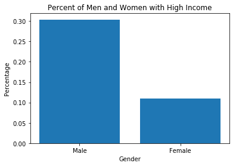

```python
plt.figure()

pos = np.arange(len(genders))
# Low income men, High income men, Low income women, High income women
num = np.sum(high_income_counts, axis=(1,2,3,4))
num = np.divide(num, num + np.sum(low_income_counts, axis=(1,2,3,4)))
plt.bar(pos, num, align='center')
plt.xticks(pos, genders)
plt.xlabel('Gender')
plt.ylabel('Percentage')
plt.title('Percent of Men and Women with High Income')

plt.show()
```

#### Plot 2 - Percent of People with High Income based on Race

To create our second plot, we call plt.figure again to make sure we plot it separately from the first one. We find the number of people who make more than $50k/yr by race using the same 5-dimensional array we created, taking only the race column and ignoring other traits. We then find the actual percentage and plot it again.

Simply looking at the bar chart, we can see that Asian-Pacific Islanders have a higher percentage of people with high income, followed by White, then Others, Blacks, and American Indian-Eskimo.

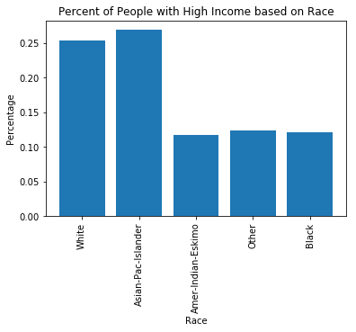

```python
plt.figure()

pos = np.arange(len(races))
num = np.sum(high_income_counts, axis=(0,2,3,4))
num = np.divide(num, num + np.sum(low_income_counts, axis=(0,2,3,4)))
plt.bar(pos, num, align='center')
plt.xticks(pos, races, rotation='vertical')
plt.xlabel('Race')
plt.ylabel('Percentage')
plt.title('Percent of People with High Income based on Race')

plt.show()
```

#### Plot 3 - Percent of People with High Income based on Workclass

After looking at genders and races, we decided to look at one’s work class. Using the same 5-dimensional matrix, and clearing the plot, we discovered that people who labeled themselves as “incorporated self-employed” have the highest percentage of getting a high income, followed by employed by the federal government, local government, unincorporated self employed, state government, private, without pay, and never worked, in descending order.

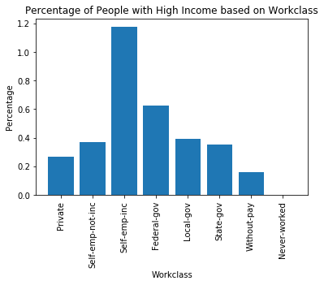

```python
plt.figure()

pos = np.arange(len(employments))
num = np.sum(high_income_counts, axis=(0,1,3,4))
num = np.divide(num, np.sum(low_income_counts, axis=(0,1,3,4)))
plt.bar(pos, num, align='center')
plt.xticks(pos, employments, rotation='vertical')
plt.xlabel('Workclass')
plt.ylabel('Percentage')
plt.title('Percentage of People with High Income based on Workclass')

plt.show()
```

#### Plot 4 - Percent of People with High Income based on Marital Status

The 4th plot we have finds the correlation between marital status and high income. In this plot, we only look at the marital status and income column from our 5-dimensional matrix.

It seems like people who are married have a much higher percentage of making more than $50k per year. Leading with married civilians, followed by married armed forces, divorced, married-spouse-absent, widowed, separated, and never-married in descending order in percentage.

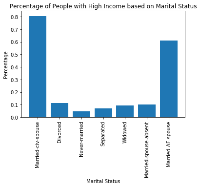

```python
plt.figure()

pos = np.arange(len(marital_statuses))
num = np.sum(high_income_counts, axis=(0,1,2,4))
num = np.divide(num, np.sum(low_income_counts, axis=(0,1,2,4)))
plt.bar(pos, num, align='center')
plt.xticks(pos, marital_statuses, rotation='vertical')
plt.xlabel('Marital Status')
plt.ylabel('Percentage')
plt.title('Percentage of People with High Income based on Marital Status')

plt.show()
```

#### Plot 5 - Percent of People with High Income based on Occupation

The last plot we looked at is correlation between occupation and high income. We look at only the occupation column and the income column while ignoring all other traits.

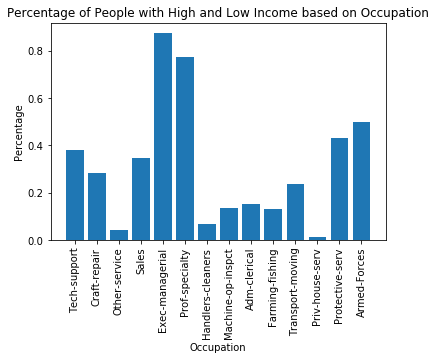

```python
plt.figure()

pos = np.arange(len(occupations))
num = np.sum(high_income_counts, axis=(0,1,2,3))
num = np.divide(num, np.sum(low_income_counts, axis=(0,1,2,3)))
plt.bar(pos, num, align='center')
plt.xticks(pos, occupations, rotation='vertical')
plt.xlabel('Occupation')
plt.ylabel('Percentage')
plt.title('Percentage of People with High and Low Income based on Occupation')

plt.show()
```

```python
rankings = np.argsort(num)[::-1]
for x in rankings:
    print('{}:{}'.format(occupations[x], num[x]))
```

```
Exec-managerial:0.8747415066469719
Prof-specialty:0.7757263100733098
Armed-Forces:0.5
Protective-serv:0.4315068493150685
Tech-support:0.38198198198198197
Sales:0.3456818708034267
Craft-repair:0.28245787908820613
Transport-moving:0.23918327661643168
Adm-clerical:0.15283165244375485
Machine-op-inspct:0.1358198451794511
Farming-fishing:0.13111268603827073
Handlers-cleaners:0.06746411483253588
Other-service:0.041855873642645605
Priv-house-serv:0.011904761904761904
```

#### Plotting maps

To make plots by location, we need to do a little more formatting work.

#### Country Abbreviations

```python
file = open('world-countries.json')
world_countries = json.load(file)
file.close()

features = world_countries['features']
name_ids = {country['properties']['name']:country['id'] for country in features}
```

#### Data Cleaning

The following block of code changes the entries in our dataset in order to provide accurate mappings.

Looking at the countries provided in the data, there are several errors, including spelling mistakes and insufficient data. For an example, "Hong", is missing the word "Kong". Sine Folium doesn't have the geotag for Hong Kong, we will put Hong Kong in China. England and Scotland are in United Kingdom, while Holland is mispelled and is in Netherlands. Moreover, Colombia is mispelled as "Columbia". According to the geo json file that folium has, United States' name is "United States of America". Furthermore, the "&'s" in the file is spelled out as "and". Last but not least, "Trinidad" is mispelled as "Trinadad".

```python
data['native-country'] = data['native-country'].map(lambda x: x.replace("-"," "))
data['native-country'] = data['native-country'].map(lambda x: x.replace("Hong","China"))
data['native-country'] = data['native-country'].map(lambda x:
                                                    x.replace("England","United Kingdom"))
data['native-country'] = data['native-country'].map(lambda x:
                                                    x.replace("Scotland","United Kingdom"))
data['native-country'] = data['native-country'].map(lambda x: x.replace("Holand ",""))
data['native-country'] = data['native-country'].map(lambda x: x.replace("Columbia","Colombia"))
data['native-country'] = data['native-country'].map(lambda x:
                                                    x.replace("United States","United States of America"))
data['native-country'] = data['native-country'].map(lambda x: x.replace("&"," and "))
data['native-country'] = data['native-country'].map(lambda x: x.replace("Trinadad","Trinidad"))
```

#### Finding Total

As the dataset contains data from people of different countries, we would like to find the ratio of people who make more than \$50k per year from each country. In order to do so, we first need to find the total number of people from each country.

The list of unknowns are countries that cannot be mapped as the folium json file does not contain information about their countries.

The total_country dictionary contains the number of people from each country that are in this dataset.

By iterating the dataset, we can then find the country that each person is from, then find the country abbreviation from the name_ids dictionary we made earlier. For each entry add 1 to the appropriate country in order to get the total.

```python
unknown = []
total_country = {}
for index, row in data.iterrows():
    if row["native-country"] in name_ids.keys():
        if name_ids[row["native-country"]] in total_country.keys():
            total_country[name_ids[row["native-country"]]] += 1
        else:
            total_country[name_ids[row["native-country"]]] = 1
    else:
        unknown.append(row["native-country"])
```

#### Missing Entries

Now let's print out a list a missing entries that we are unable to map.

```python
unknown = set(unknown)
print("Here's a list of countries that cannot be mapped: {}".format(unknown))
```

```
Here's a list of countries that cannot be mapped: {'Outlying US(Guam USVI etc)', 'Yugoslavia', 'South'}
```

#### Finding Ratio

```python
low_income = {}
for index,row in data.iterrows():
    if row["native-country"] in name_ids.keys():
        if name_ids[row["native-country"]] in low_income.keys():
            low_income[name_ids[row["native-country"]]] += row["num_income"]
        else:
            low_income[name_ids[row["native-country"]]] = row["num_income"]
```

Now put ratio as a panda dataframe, with columns "country" and "ratio". Print the head (first five items) to see how it looks like!

```python
ratio = {k:(total_country[k]-low_income[k])/total_country[k]*100 for k in low_income.keys()}
s = pd.DataFrame(list(ratio.items()),columns=['country', 'ratio'])
s.head()
```

|  | country | ratio |
| --- | --- | --- |
| 0 | ECU | 86.666667 |
| 1 | THA | 83.333333 |
| 2 | NIC | 93.877551 |
| 3 | VNM | 91.954023 |
| 4 | POL | 80.681818 |

#### Map1 - Percent of Adults Making Less than 50k/yr by Country

Now let's put our information and visualize it on a map!

First, set up a folium map by calling folium.Map(). The world geo tags are from a file called "world-countries.json" from folium, https://github.com/python-visualization/folium/blob/master/examples/data/world-countries.json.

Then, using the pandas dataframe, s, that we obtained from our dictionary ratio, use it as a parameter to plot a choropleth map. We chose the option "YlGn" (yellow and green) as it's easier to read.

```python
map = folium.Map()
world_geo = r'world-countries.json'
map.choropleth(geo_path=world_geo, data=s,
             columns=['country', 'ratio'],
             key_on='feature.id',
             fill_color='YlGn', fill_opacity=0.7, line_opacity=0.2,
              legend_name='% of adults making less than $50k/yr by country')
map
```

[interactive chart not shown]

We are also attaching a screenshot of the map in case folium doesn't show:

[figure not shown]

#### Average Education Level by Country

As we already have the total number of entries from each country, all we need is the total sum of rank of education levels by country (column 4, under "educational-num). In order to get the number, we have to iterate through the dataset, and find the educational num column to obtain its rank. Then add the rank to its respective country like we did before.

```python
education_overall = {}
for index,row in data.iterrows():
    if row["native-country"] in name_ids.keys():
        if name_ids[row["native-country"]] in education_overall.keys():
            education_overall[name_ids[row["native-country"]]] += row["educational-num"]
        else:
            education_overall[name_ids[row["native-country"]]] = row["educational-num"]
```

By dividing the total overal education by the total number of entry will get an average education level for the people from each country as a whole. Put that number in a dictionary called edu_percent.

Now put edu_percent as a pandas dataframe, let's call it s_edu, with columns "country" and "education". Print the head (first five items) to see how it looks like!

```python
edu_percent = {k:education_overall[k]/total_country[k] for k in total_country.keys()}
s_edu = pd.DataFrame(list(edu_percent.items()),columns=['country', 'education'])

s_edu.head()
```

|  | country | education |
| --- | --- | --- |
| 0 | ECU | 9.244444 |
| 1 | THA | 10.833333 |
| 2 | NIC | 9.000000 |
| 3 | VNM | 9.609195 |
| 4 | POL | 10.102273 |

#### Map2 - Education Level of Adults by Country

First, set up a new folium map. Use the same world geo tags from before, world-countries.json.

In order for readers to understand the map, we used the same color option as before, yellow and green.

The darker the country, the more educated the people from it in the dataset are.

```python
map = folium.Map()
world_geo = r'world-countries.json'
map.choropleth(geo_path=world_geo, data=s_edu,
             columns=['country', 'education'],
             key_on='feature.id',
             fill_color='YlGn', fill_opacity=0.7, line_opacity=0.2,
             legend_name="Education Level Scale")
map
```

[interactive chart not shown]

We are also attaching a screenshot of the map in case folium doesn't show:

[figure not shown]

## Hypothesis Testing

First we need to generate a list of the other races to compare Asians against.

```python
comparable_races = list(races)
comparable_races.remove('Asian-Pac-Islander')
```

Using a Student's t-test, from `scipy`, we can calculate the probability that the mean salary of Asians is similar to that of each of the other races.

```python
print('Probability that mean salaries are equal to the mean salaries of Asians.')
asian_sample = data[data['race'] == 'Asian-Pac-Islander']['num_income']
for race in comparable_races:
    other_sample = data[data['race'] == race]['num_income']
    (t,p) = scipy.stats.ttest_ind(asian_sample, other_sample, equal_var=False)
    print('{}: {}'.format(race, p))
all_others = data[data['race'] != 'Asian-Pac-Islander']['num_income']
(t,p) = scipy.stats.ttest_ind(asian_sample, all_others, equal_var=False)
print('All non-Asians: {}'.format(p))
```

```
Probability that mean salaries are equal to the mean salaries of Asians.
White: 0.18758718893442164
Amer-Indian-Eskimo: 1.1081975038508744e-15
Other: 5.049470571194924e-13
Black: 2.8864232055367824e-32
All non-Asians: 0.007482024869307618
```

We can extend this statistical test to find the probability that the mean salary of Asians is greater than that of each of the other races.

```python
print('Probability that mean salaries are less than the mean salaries of Asians.')
asian_sample = data[data['race'] == 'Asian-Pac-Islander']['num_income']
for race in comparable_races:
    other_sample = data[data['race'] == race]['num_income']
    (t,p) = scipy.stats.ttest_ind(asian_sample, other_sample, equal_var=False)
    p = 1 - p / 2
    print('{}: {}'.format(race, p))
all_others = data[data['race'] != 'Asian-Pac-Islander']['num_income']
(t,p) = scipy.stats.ttest_ind(asian_sample, all_others, equal_var=False)
p = 1 - p / 2
print('All non-Asians: {}'.format(p))
```

```
Probability that mean salaries are less than the mean salaries of Asians.
White: 0.9062064055327892
Amer-Indian-Eskimo: 0.9999999999999994
Other: 0.9999999999997475
Black: 1.0
All non-Asians: 0.9962589875653461
```

Based on these tests, we can see that with α = 0.01, the percentage of Asians with salaries greater than \$50k is higher than that of all other races combined, and higher than that of each individual race except for White.

## Machine Learning

To train models on our data we must first encode it appropriately. `sklearn` does not accept categorical variables, which have a few classes, but will only take numerical data. To make it accept our data we need to first use the `pandas.get_dummies` function on our categorical columns to convert them to numerical data. The function encodes each possible category of the data as a separate feature, so that rows which were in a specific category instead have a 1 for the feature representing that category and a 0 for features representing the other categories.

```python
categorical_cols = ['workclass', 'marital-status', 'occupation',
                    'relationship', 'race', 'gender', 'native-country']
input_columns = ['age', 'workclass', 'educational-num', 'marital-status',
                 'occupation', 'relationship', 'race', 'gender', 'native-country']
output_column = 'num_income'

onehot_enc = pd.get_dummies(data[input_columns], columns=categorical_cols)
X = onehot_enc.as_matrix()
y = data[output_column].as_matrix()
```

We also want to split up our data into a training and testing set, so that we can accurately test how well our model predicts the data after training without letting it 'cheat' by seeing the testing data. We do this with the `sklearn.model_selection.train_test_split` function.

```python
X_train, X_test, y_train, y_test = sklearn.model_selection.train_test_split(X, y, test_size=0.25)
```

However, we don't know what type of model will predict our data best, so we need to test a couple that seem good. To do this we use 10-fold cross-validation to compare a Random Forest, KNN, and Logistic Regression model. The cross-validation compares how well the different classifiers perform while being trained and tested on different subsets of the training data.  
We also use the `warnings` module here to capture deprecation warnings, which cross_val_score emits due to its use of older numpy functions.

```python
n_train = X_train.shape[0]
n_folds = 10

rf_clf = sklearn.ensemble.RandomForestClassifier()
knn_clf = sklearn.neighbors.KNeighborsClassifier(n_neighbors=np.sqrt(n_train))
lgr_clf = sklearn.linear_model.LogisticRegression()

# ignore deprecation error
with warnings.catch_warnings():
    warnings.simplefilter('ignore')

    rf_scores = sklearn.model_selection.cross_val_score(rf_clf, X_train, y_train, cv=n_folds)
    knn_scores = sklearn.model_selection.cross_val_score(knn_clf, X_train, y_train, cv=n_folds)
    lgr_scores = sklearn.model_selection.cross_val_score(lgr_clf, X_train, y_train, cv=n_folds)
```

Having computed the cross validation scores, we can now compare them to determine the best model. We use a t-test to compare their scores.

```python
t_val, p_val = scipy.stats.ttest_ind(rf_scores, knn_scores)
print('Probability Random Forest and KNN have similar mean accuracy:')
print('\tt = {}\n\tp = {}'.format(t_val, p_val))
print('Probability Random Forest is superior:')
print('\tp = {}'.format(p_val/2))
```

```
Probability Random Forest and KNN have similar mean accuracy:
	t = -6.225452856028759
	p = 7.125779029677536e-06
Probability Random Forest is superior:
	p = 3.562889514838768e-06
```

Based on this, we can conclude that a KNN will better model the data than a Random Forest classifier.

```python
t_val, p_val = scipy.stats.ttest_ind(knn_scores, lgr_scores)
print('Probability KNN and Logistic Regression have similar mean accuracy:')
print('\tt = {}\n\tp = {}'.format(t_val, p_val))
print('Probability KNN is superior:')
print('\tp = {}'.format(p_val/2))
```

```
Probability KNN and Logistic Regression have similar mean accuracy:
	t = -4.2500702190509525
	p = 0.0004815877129892701
Probability KNN is superior:
	p = 0.00024079385649463506
```

Based on these results, we can conclude that a Logistic Regression Classifier is more accurate than both the KNN and Random Forest classifiers.

```python
model = sklearn.linear_model.LogisticRegression()
model.fit(X_train, y_train)
print(model.score(X_test, y_test))
```

```
0.827860126116
```

We can see from this that our final accuracy on the testing data is about 82%.

## Additional Reading and Sources

One of the reasons this data (and analysis) is important is because it highlights a number of important characterists about the American job market that all Americans should have in mind.

This includes information on jobs that are earning employees the most money on average, jobs employees might find the most satisfying, characterists that might be discriminated against (intentionally or otherwise), income inequality and the wage gap, the developing state of the job market (up-and-coming vs declining jobs), and more.

Here are a few sources which highlight some of the issues that a career-ready individual might want to consider when either entering or advancing in the job market.

Income Inequality:

1. http://inequality.org/inequality-data-statistics/
2. http://www.bmj.com/content/321/7272/1311.short
3. http://piketty.pse.ens.fr/files/Bakijaetal2010.pdf

Highest Paying Jobs:

1. http://www.businessinsider.com/highest-paying-jobs-in-america-2017-4/#25-sales-manager-1
2. https://80000hours.org/articles/highest-paying-jobs/
3. http://journals.sagepub.com/doi/abs/10.1177/001979390105500101
4. http://journals.sagepub.com/doi/full/10.1177/0950017013480403

Discrimination in the workplace:

1. https://www.eeoc.gov/laws/types/
2. https://www.thebalance.com/types-of-employment-discrimination-with-examples-2060914
3. http://employment.findlaw.com/employment-discrimination/facts-about-race-color-discrimination.html
4. http://employment.findlaw.com/employment-discrimination/sex-gender-discrimination-overview.htm

Job satisfaction:

1. http://journals.sagepub.com/doi/abs/10.1177/014920639101700305
2. http://www.sciencedirect.com/science/article/pii/S1053535700000858
3. http://onlinelibrary.wiley.com/doi/10.1111/j.2044-8325.1996.tb00600.x/full